# Ch. 3: Oil production and ambient air quality in California

Results - Monthly Annuli New Wells (no wind)

## Pollutant: CO

**Notes:**

- We used data from 140 monitors and 17405 monitor-months, from 1999-01-01 to 2019-12-01
- We droppped the 67 monitor-months that had nonsensical mean monthly CO concentrations of ≤ 0 µg/m^3,

#### FE for monitor + air basin-month + year

| distance | point_est | ci_lower | ci_upper | n_wells |
| --- | --- | --- | --- | --- |
| 0-1 | NaN | NaN | NaN | 17 |
| 1-2 | -0.1219044905 | -0.26686146 | 0.02305248 | 78 |
| 2-3 | 0.0009832627 | -0.10894289 | 0.11090942 | 98 |
| 3-4 | 0.1033211943 | 0.04720513 | 0.15943726 | 183 |
| 4-5 | -0.2841959438 | -0.44852495 | -0.11986694 | 123 |
| 5-6 | -0.0172527026 | -0.13360969 | 0.09910429 | 145 |
| 6-7 | -0.1090862097 | -0.15474322 | -0.06342920 | 150 |
| 7-8 | -0.0073166880 | -0.04511321 | 0.03047983 | 144 |
| 8-9 | -0.0226080074 | -0.07380099 | 0.02858498 | 129 |
| 9-10 | 0.0136240918 | -0.02973819 | 0.05698637 | 80 |

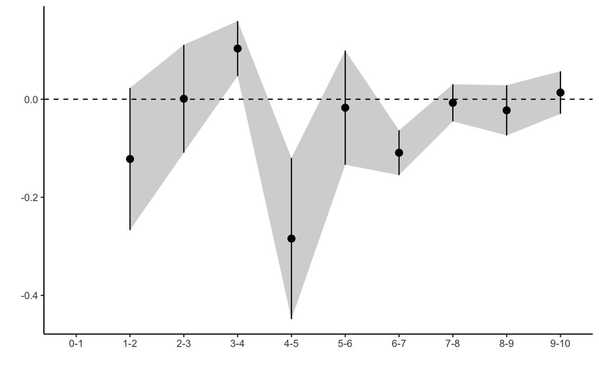

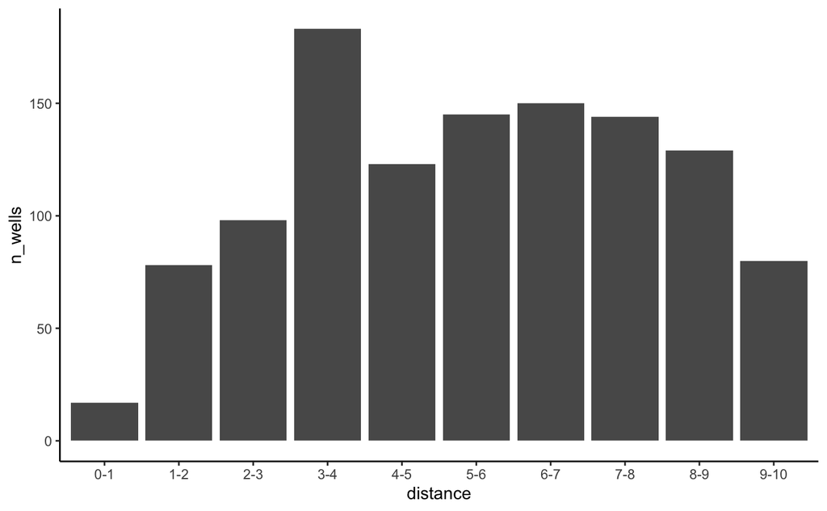

## Pollutant: NO2

**Notes:**

- We used data from 164 monitors and 24052 monitor-months, from 1999-01-01 to 2019-12-01
- We droppped the 2 monitor-months that had nonsensical mean monthly NO2 concentrations of ≤ 0 µg/m^3,

#### Adjusted model with basin-month + year + monitor FE

| distance | point_est | ci_lower | ci_upper |
| --- | --- | --- | --- |
| 0-1 | 5.0974016 | -8.93997858 | 19.13478172 |
| 1-2 | -1.1832025 | -2.43722450 | 0.07081948 |
| 2-3 | 0.4196470 | -1.21441312 | 2.05370703 |
| 3-4 | 0.4315137 | -0.19299161 | 1.05601892 |
| 4-5 | -1.1835559 | -2.60335873 | 0.23624701 |
| 5-6 | -0.6344565 | -2.23330853 | 0.96439558 |
| 6-7 | -0.9713557 | -1.80029996 | -0.14241140 |
| 7-8 | 0.6678377 | -0.02426018 | 1.35993557 |
| 8-9 | -0.6342762 | -1.59255275 | 0.32400028 |
| 9-10 | 0.5607746 | -0.22961803 | 1.35116720 |

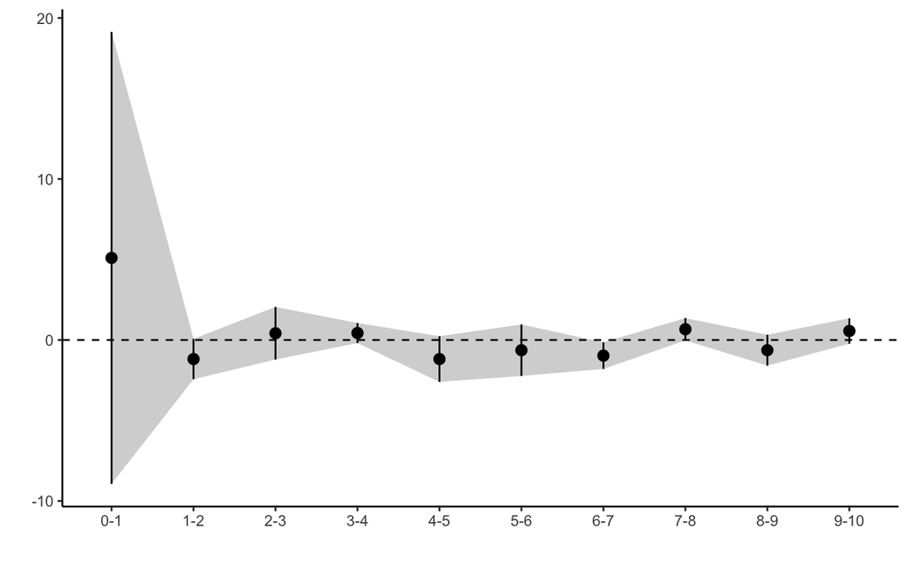

## Pollutant: O3

**Notes:**

#### Crude model

```
Call:
   felm(formula = monthly_mean_ozone ~ wells_preprod_0to1km + wells_preprod_1to2km +      wells_preprod_2to3km + wells_preprod_3to4km + wells_preprod_4to5km +      wells_preprod_5to6km + wells_preprod_6to7km + wells_preprod_7to8km +      wells_preprod_8to9km + wells_preprod_9to10km, data = subset(aq…

Residuals:
      Min        1Q    Median        3Q       Max
-0.042986 -0.009610 -0.001062  0.008508  0.056647

Coefficients:
                        Estimate Std. Error t value Pr(>|t|)
(Intercept)            4.332e-02  6.464e-05 670.165   <2e-16 ***
wells_preprod_0to1km   6.803e-03  2.307e-03   2.948   0.0032 **
wells_preprod_1to2km  -1.351e-03  8.663e-04  -1.559   0.1189
wells_preprod_2to3km   7.284e-04  1.140e-03   0.639   0.5229
wells_preprod_3to4km   8.939e-04  6.350e-04   1.408   0.1592
wells_preprod_4to5km  -8.163e-04  1.089e-03  -0.749   0.4536
wells_preprod_5to6km   1.643e-03  8.513e-04   1.930   0.0536 .
wells_preprod_6to7km   3.217e-05  5.616e-04   0.057   0.9543
wells_preprod_7to8km   6.796e-04  8.232e-04   0.826   0.4090
wells_preprod_8to9km   2.029e-04  9.271e-04   0.219   0.8268
wells_preprod_9to10km  7.175e-04  9.717e-04   0.738   0.4603
---
Signif. codes:  0 ‘***’ 0.001 ‘**’ 0.01 ‘*’ 0.05 ‘.’ 0.1 ‘ ’ 1

Residual standard error: 0.0138 on 45760 degrees of freedom
Multiple R-squared(full model): 0.0005682   Adjusted R-squared: 0.0003498
Multiple R-squared(proj model): 0.0005682   Adjusted R-squared: 0.0003498
F-statistic(full model):2.601 on 10 and 45760 DF, p-value: 0.003728
F-statistic(proj model): 2.601 on 10 and 45760 DF, p-value: 0.003728
```

#### FE for monitor + air basin-month + year

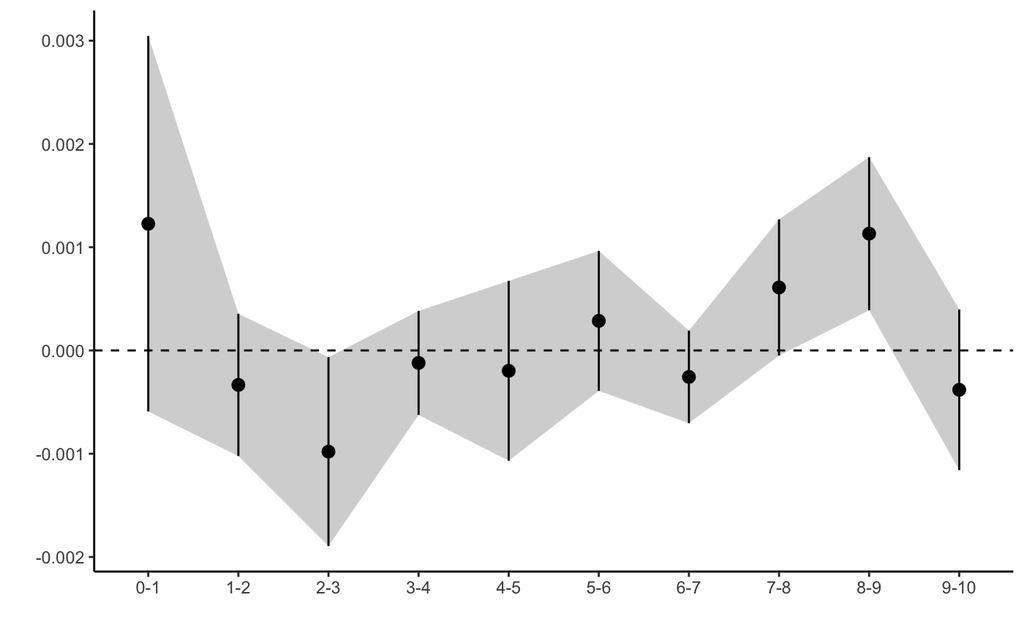

## Pollutant: PM2.5

**Notes:**

- We used data from 151 monitors and 21193 monitor-months, from 1999-01-01 to 2019-12-01
- We droppped the 29 monitor-months that had nonsensical mean monthly PM2.5 concentrations of ≤ 0 µg/m^3,

#### Adjusted model with basin-month + year + monitor FE

| distance | point_est | ci_lower | ci_upper |
| --- | --- | --- | --- |
| 0-1 | NaN | NaN | NaN |
| 1-2 | -1.51296900 | -4.2079088 | 1.1819708 |
| 2-3 | 1.82762467 | 0.2723788 | 3.3828706 |
| 3-4 | -0.07508577 | -1.0359479 | 0.8857764 |
| 4-5 | 1.52679893 | -1.3272858 | 4.3808837 |
| 5-6 | 1.00387426 | -1.8260080 | 3.8337565 |
| 6-7 | -0.13848046 | -0.9426325 | 0.6656716 |
| 7-8 | -0.07404573 | -0.9118430 | 0.7637515 |
| 8-9 | 0.11038818 | -0.9010966 | 1.1218730 |
| 9-10 | -0.57867311 | -1.3192106 | 0.1618644 |

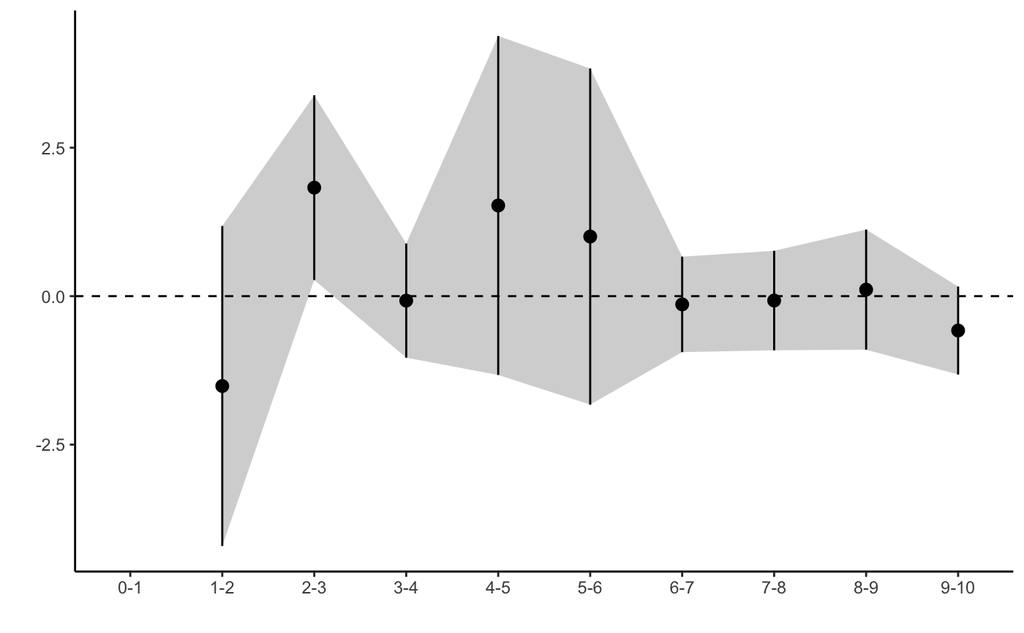

## Pollutant: SO2

**Notes:**

#### Crude model

```
the matrix is either rank-deficient or indefinite
```

```
Call:
   felm(formula = monthly_mean_so2 ~ wells_preprod_0to1km + wells_preprod_1to2km +      wells_preprod_2to3km + wells_preprod_3to4km + wells_preprod_4to5km +      wells_preprod_5to6km + wells_preprod_6to7km + wells_preprod_7to8km +      wells_preprod_8to9km + wells_preprod_9to10km, data = subset(aqs_…

Residuals:
   Min     1Q Median     3Q    Max
-6.424 -1.753 -0.798  0.881 34.881

Coefficients:
                      Estimate Std. Error t value Pr(>|t|)
(Intercept)            2.78521    0.03248  85.745  < 2e-16 ***
wells_preprod_0to1km        NA         NA      NA       NA
wells_preprod_1to2km  -1.20249    0.92916  -1.294 0.195645
wells_preprod_2to3km   3.46855    1.96502   1.765 0.077581 .
wells_preprod_3to4km   1.45168    0.53134   2.732 0.006308 **
wells_preprod_4to5km  -0.72066    1.07482  -0.670 0.502564
wells_preprod_5to6km   0.55995    1.41707   0.395 0.692746
wells_preprod_6to7km   0.36787    0.94099   0.391 0.695856
wells_preprod_7to8km  -0.28996    0.26198  -1.107 0.268406
wells_preprod_8to9km   1.39438    0.38910   3.584 0.000341 ***
wells_preprod_9to10km -0.39926    0.98437  -0.406 0.685049
---
Signif. codes:  0 ‘***’ 0.001 ‘**’ 0.01 ‘*’ 0.05 ‘.’ 0.1 ‘ ’ 1

Residual standard error: 2.779 on 7399 degrees of freedom
Multiple R-squared(full model): 0.003496   Adjusted R-squared: 0.002284
Multiple R-squared(proj model): 0.003496   Adjusted R-squared: 0.002284
F-statistic(full model):2.884 on 9 and 7399 DF, p-value: 0.002101
F-statistic(proj model): 2.596 on 10 and 7399 DF, p-value: 0.003838
```

#### Adjusted model with basin-month + year + monitor FE

| distance | point_est | ci_lower | ci_upper |
| --- | --- | --- | --- |
| 0-1 | NaN | NaN | NaN |
| 1-2 | -3.4104822 | -4.5104539 | -2.3105105 |
| 2-3 | -0.4415861 | -2.7484986 | 1.8653264 |
| 3-4 | 0.1986405 | -0.4561429 | 0.8534240 |
| 4-5 | -0.7983107 | -2.0645882 | 0.4679668 |
| 5-6 | 0.2474693 | -1.4243513 | 1.9192898 |
| 6-7 | -0.9344261 | -2.0495121 | 0.1806600 |
| 7-8 | -0.5232071 | -0.8402804 | -0.2061339 |
| 8-9 | -0.8102889 | -1.2834707 | -0.3371072 |
| 9-10 | -1.0352689 | -2.1948153 | 0.1242774 |

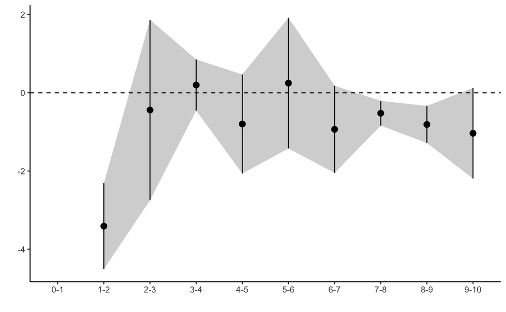